# Consulting Open Ended Assignment

Robert Thomas Kohn

11/16/25

# BUDGET DATA ANALYSIS

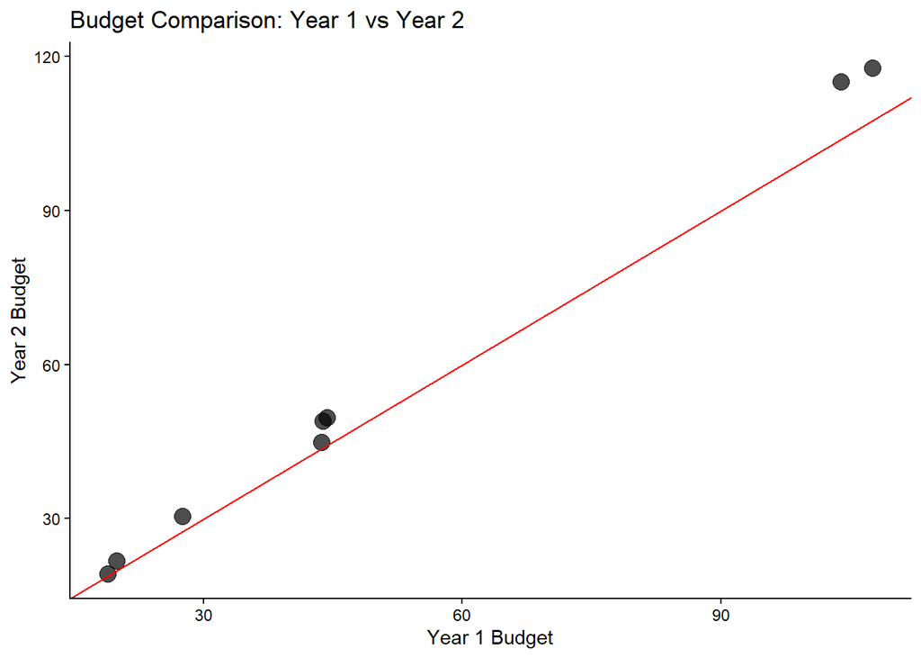

```r
budget = read.table("https://raw.githubusercontent.com/JedStephens/Handbook-of-Small-Data-Sets/master/BUDGET.DAT")
budget = budget %>% rename(Year1 = V1, Year2 = V2)

gf_point(Year2 ~ Year1, data = budget, size = 4, alpha = 0.7) %>%gf_abline(slope = 1, intercept = 0, color = "red") %>%gf_labs(title = "Budget Comparison: Year 1 vs Year 2", x = "Year 1 Budget", y = "Year 2 Budget")
```

I thought a scatter plot was a good demonstration as it shows a good relationship between the two years budgets. The redline I added shows where the budgets would be equal. However, it also adds clarity about just how year 2 has a greater budget for both. I went with alpha level of .7 for clarity and size 4 for the same reason as well as the fact it shows how close it can be without being there. The main takeaway is nothing crazy but the budget certainly increased.

# WHISKY DATA ANALYSIS

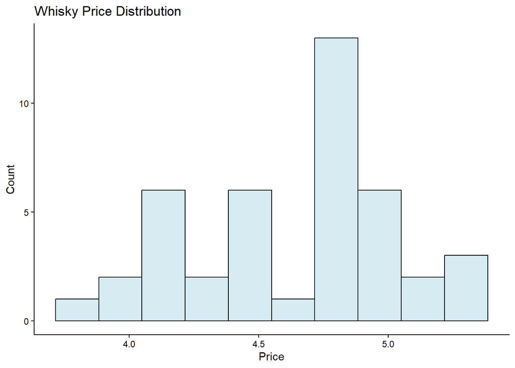

```r
whisky_lines = readLines("https://raw.githubusercontent.com/JedStephens/Handbook-of-Small-Data-Sets/master/WHISKY.DAT")#ChatGPT Fix to make this run)
whisky = data.frame(Price = na.omit(as.numeric(unlist(strsplit(whisky_lines, ",")))))
whisky = data.frame(Price = na.omit(unlist(whisky)))
gf_histogram(~Price, data = whisky, fill = "lightblue", color = "black",bins=10) %>%gf_labs(title = "Whisky Price Distribution",x = "Price", y = "Count")
```

I thought that a histogram was best for this dataset about Whisky Prices. It enables me to show a proper price distribution to the viewer for easy understanding. I wanted this to be very simple overall so it was easy to understand so choosing simple labels and colors was ideal. The main takeaway is that prices typically cluster from 4.50 to 5 dollars. A bin size of 10 guaranteed data would be represented without overcluttering.

# EXAM DATA ANALYSIS

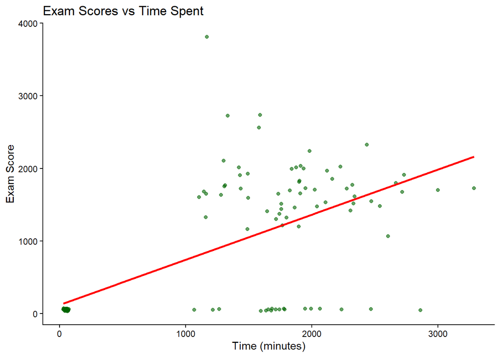

```r
exam_lines = readLines("https://raw.githubusercontent.com/JedStephens/Handbook-of-Small-Data-Sets/master/EXAM.DAT")#GPT Fix
exam_values = na.omit(as.numeric(unlist(strsplit(exam_lines, "\\s+"))))
scores = exam_values[seq(1, length(exam_values), 2)]
times = exam_values[seq(2, length(exam_values), 2)]
exam = data.frame(Score = scores, Time = times)
exam = data.frame(Score = na.omit(unlist(exam[seq(1, nrow(exam), 2), ])),Time = na.omit(unlist(exam[seq(2, nrow(exam), 2), ])))

gf_point(Score ~ Time, data = exam, color = "darkgreen", alpha = 0.6) %>% gf_smooth(method = "lm", color = "red") %>% gf_labs(title = "Exam Scores vs Time Spent", x = "Time (minutes)", y = "Exam Score")
```

I believe the scatterplot optimally shows both the times and scores alongside their relationship in the most simple visual manner. I thought green points with a red trendline was ideal as it has strong contrast, Green opposes Red. There is a weak positive relationship as more time doesn’t inherently guarantee higher scores but it was still interesting no less.